# NLP Workshop

# Before we get started

link to lesson plan: https://ucdavisdatalab.github.io/workshop-nlp-healthcare/

If you will be coding along please check that you have R and RStudio installed on your machine.

# Introductions

#### b. About you

Word frequencies Bigrams

# Objectives for this Workshop

```
1. Explain natural language processing in lay terms
2. Give examples of NLP applications for research
3. Evaluate particular challenges posed by working with health data
4. Describe key text mining and NLP metrics for assessing word importance and document similarity
    - Install the 'tm' package in R
    - Create a corpus and DocumentTermMatrix
    - Calculate word frequencies
    - Calculate TF-IDF weighting
    - Generate PCA for exploring document similarities
5. identify where to go to learn more!
```

# Intro to NLP

There is *a lot* of health data that is unstrctured text.

- EMR
- Clinical notes
- Medical journal literature
- Surveys and questionnaires
- Interviews
- Community forums
- Social media

NLP allows us to use “distance reading” to unlock information from narrative text for extraction and classification:

- keyword detection
- topic detection
- document summarizing
- document classification
- document clustering
- document similarity
- speech recognition
- text translation

*Natural Language Processing* (NLP) = linguistics + computer science + information engineering + data science. We use NLP to computationally parse and analyze large amounts of natural language data.

NLP takes **text to numbers and numbers to machines.**

#### What’s a Natural Language?

“…any language that has evolved naturally in humans through use and repetition without conscious planning or premeditation. Natural languages can take different forms, such as speech or signing. They are distinguished from constructed and formal languages such as those used to program computers or to study logic.” [Thanks, Wikipedia.](https://en.wikipedia.org/wiki/Natural_language)

**Thought questions:** Are clinical notes a natural language? What about tweets?

#### History of NLP

1950s - Alan Turing’s article on “Computing Machinery and Intelligence” 1954 - Georgetown Experiment to automatically translate 60 Russian sentences to English 1960s - Restricted vocabularies 1970s - Conceptual ontologies and chatterbots 1980s - First statistical machine translation systems developed (IBM, Watson) 2010s - Extensions of classical NLP and emergence of deep neural networks

In this workshop we’re focusing on classical NLP (feature engineering).

#### Caveats before we get started

**Garbage in, garbage out.** Know your corpus. **All models are wrong, but some are useful.** And others are dangerous.

*Natural langauge data can not be deidentified.*

NLP models are powerful, but can fail when applied to jargon-heavy, niched domains. Augmenting with developed medical dictionaries helps, but parts of speech taggers, for example, are not designed for the health space. This is especially true for classical NLP techniques, although deep learning approaches hold strong promise for working with unstructured health data.

#### Text processing

```
- *word frequency*:
- *TF-IDF*:
- *PCA*:
- word dispersion:
- KWIC: Key Word in Context
- co-occurence:
- stemming:
- bigrams: conditional probability of a token given the preceding token.
- named entity recognition (NER): identifying which items in the text map to proper names (people, places, location).
- regular expressions (RegEx): searching for exact words, parts of words or phrases
- feature extraction:
- document clustering (e.g kmeans)
- parsing: grammatical analysis of a sentence and relationships between words.
- feature based linear classifiers:
- topic modeling:
- word embedding: mapping words or phrases to vectors of real numbers allowing words with similar meaning to have a similar representation.
- sentiment analysis: subjective information to determine "polarity" of a document. (e.g., positive or negative reviews)
- lemmatization - removing inflectional endings to return the base dictionary form of a word (lemma).
- part of speech tagging: determining the parts of speech for each word in a sentence.
- dependency parsing:
- OCR: optical character recognition, determining the text from an image of the text.
```

# Where to go to learn more

# Demo introduction

Dr. Sonja Diertrich is a radiation oncologist at UCDMC studying early stage breast cancer. For this coding demo we are using NLP to explore the recent literature on this topic with her lab.

#### Why R? What is RStudio?

[“R”](https://www.r-project.org/) is a programming language and statistical software that interprets scripts. [RStudio](https://rstudio.com/) is an Integrated Development Environment (IDE) for working with R. You need R installed in order to use RStudio, but you don’t need RStudio to work with R.

*So why R?* * Faciliates reproducible research workflows - integrates with other tools. - designed for data analysis - produces high-quality graphics * It’s extensible and interdisciplinary - free, open-source, well-documented, and cross-platform - runs on Mac, PC and Linux. - works with data of all shapes and sizes. - large library of external packages available for performing diverse tasks, including text mining and NLP. * Large (and growing) community

*Should you use R?* Maybe. Use whatever langauge allows you to perform your work and faciliates sharing with your direct colleagues and the broader reserach community.

# Setup

#### a. objectives

```
1. Show how to store and clean text data with the 'tm' package
2. Introduce Bag of Words representation of documents
3. Demonstrate how to create and use a DocumentTermMatrix
4. Explain and demonstrate TF-IDF weighting
5. Explain PCA and its applications for corpus exploration
```

#### b. packages needed

Run this command if you don’t already have these packages installed.

```r
install.packages('tm')
install.packages('ggplot2')
install.packages('Matrix')
```

Once the packages are installed, load them into your R environment.

```r
library('tm')
```

```r
library('ggplot2')
library('Matrix')
```

You can find the documentation for the package [online](https://cran.r-project.org/web/packages/tm/tm.pdf)  
Within R/RStudio you can browse function documentation with the following syntax.

```
?TermDocumentMatrix
```

#### c. data for this workshop

```r
data <- read.csv(url("https://ucdavisdatalab.github.io/workshop-nlp-healthcare/abstracts.csv"), stringsAsFactors=FALSE)
head(data)
```

```
##   authors year
## 1         2008
## 2         2014
## 3         2015
## 4         2016
## 5         2016
## 6         2017
##                                                                                                                                                                                                                                                                                                          …
## 1                                                                                                                                                     The UK Standardisation of Breast Radiotherapy (START) Trial B of radiotherapy hypofractionation for treatment of early breast cancer: a randomised …
## 2 Erratum: Effect of radiotherapy after mastectomy and axillary surgery on 10-year recurrence and 20-year breast cancer mortality: meta-analysis of individual patient data for 8135 women in 22 randomised trials (The Lancet (2014) 383(9935) (2127–2135)(S0140673614604888)(10.1016/S0140-6736(14)6048…
## 3                                                                                                                                                                                                                   Proceedings of the American Society for Radiation Oncology 57th Annual Meeting, ASTRO…
## 4                                                                                                                                                                                              Late-Breaking Abstracts from the 57th Annual Meeting of the American Society for Radiation Oncology, ASTRO…
## 5                                                                                                                                                                                                                                       Proceedings of the American Society for Radiation Oncology, ASTRO…
## 6                                                                                                                                                                                                                                                            2017 ASTRO Annual Meeting Late-Breaking Abst…
##                                                       journal
## 1                                                  The Lancet
## 2                                                  The Lancet
## 3 International Journal of Radiation Oncology Biology Physics
## 4 International Journal of Radiation Oncology Biology Physics
## 5                 International Journal of Radiation Oncology
## 6 International Journal of Radiation Oncology Biology Physics
##                                                                                                                                                                                                                                                                                                          …
## 1 Background: The international standard radiotherapy schedule for early breast cancer delivers 50 Gy in 25 fractions of 2·0 Gy over 5 weeks, but there is a long history of non-standard regimens delivering a lower total dose using fewer, larger fractions (hypofractionation). We aimed to test the …
## 2                                                                                                                                                                                                                                                                                                        …
## 3                                                                                                                                                                                                                                                                                                        …
## 4                                                                                                                                                                                                                                                                                                        …
## 5                                                                                                                                                                                                                                                                                                        …
## 6                                                                                                                                                                                                                                                                                                        …
```

Let’s look at the text from the first abstract

```r
data$text[[1]]
```

```
## [1] "Background: The international standard radiotherapy schedule for early breast cancer delivers 50 Gy in 25 fractions of 2·0 Gy over 5 weeks, but there is a long history of non-standard regimens delivering a lower total dose using fewer, larger fractions (hypofractionation). We aimed to test t…
```

Notice that within the text there are a variety of potential issues. For example, some words are capitalized, there is punctuation, weird symbols, and numbers. For many NLP methods, we want to normalize the texts to get around these issues. The ‘tm’ package has several built in features for normalizing text. The first step is to load the text into a ‘corpus’ object.

# Preprocessing

#### a. Load the text column into a ‘corpus’ object

```r
mycorpus <- Corpus(VectorSource(data$text))
inspect(head(mycorpus))
```

```
## <<SimpleCorpus>>
## Metadata:  corpus specific: 1, document level (indexed): 0
## Content:  documents: 6
##
## [1] Background: The international standard radiotherapy schedule for early breast cancer delivers 50 Gy in 25 fractions of 2·0 Gy over 5 weeks, but there is a long history of non-standard regimens delivering a lower total dose using fewer, larger fractions (hypofractionation). We aimed to test th…
## [2] EBCTCG (Early Breast Cancer Trialists' Collaborative Group). Effect of radiotherapy after mastectomy and axillary surgery on 10-year recurrence and 20-year breast cancer mortality: meta-analysis of individual patient data for 8135 women in 22 randomised trials. Lancet 2014; 383: 2127–35—Durin…
## [3] The proceedings contain 2121 papers. The topics discussed include: radiation treatment parameters and late gastrointestinal toxicity in cervical cancer patients treated with image guided high-dose-rate brachytherapy; the effect of pelvic radiation therapy on vaginal brachytherapy cylinder siz…
## [4] The proceedings contain 12 papers. The topics discussed include: dexamethasone versus placebo in the prophylaxis of radiation-induced pain flare following palliative radiation therapy for bone metastases: a double-blind randomized, controlled, superiority trial; hypofractionated versus conven…
## [5] The proceedings contain 2300 papers. The topics discussed include: a phase III randomized control trial comparing skin-sparing helical tomotherapy versus 3D-conformal radiation therapy in early-stage breast cancer: acute and late skin toxicity outcomes; longitudinal analysis of patient-report…
## [6] The proceedings contain 16 papers. The topics discussed include: tumor treating fields (TTFields)- a novel cancer treatment modality: translating preclinical evidence and engineering into a survival benefit with delayed decline in quality of life; a randomized controlled trial evaluating the …
```

#### b. Preprocess the corpus object

Use the tm_map function to apply a transformation on each element of the corpus object.  
Alternatively use the tm_parLapply function to do the same in parallel.

```r
mycorpus <- tm_map(mycorpus, tolower)
mycorpus <- tm_map(mycorpus, removePunctuation, ucp=TRUE)
mycorpus <- tm_map(mycorpus, removeNumbers)
mycorpus <- tm_map(mycorpus, removeWords, stopwords("en"))
```

Now that we have normalized the text, lets look at the first abstract again.

```r
mycorpus[[1]]$content
```

```
## [1] "background  international standard radiotherapy schedule  early breast cancer delivers  gy   fractions   gy   weeks     long history  nonstandard regimens delivering  lower total dose using fewer larger fractions hypofractionation  aimed  test  benefits  radiotherapy schedules using fraction…
```

It looks ‘normalized’ but how do we model this? how do we apply NLP algorithms on it?

# The Bag of Words Representation

Consider:  
what is a text document to a computer?  
What can it do with a sequence of characters?

In order for us to apply statistical methods on a document, we need a representation of texts that is easy for a computer to process, but still encodes information related to that text’s content. One such representation is the Bag of Words format.

Bag of Words is a way of representing a document that encodes a document as a ‘bag’ of its tokens. The document is represented as the words that appeared in the document and the number of times those words appeared. All information about word order is lost in this representation, however, for many NLP methods, this is still an effective representation of the content of the document.

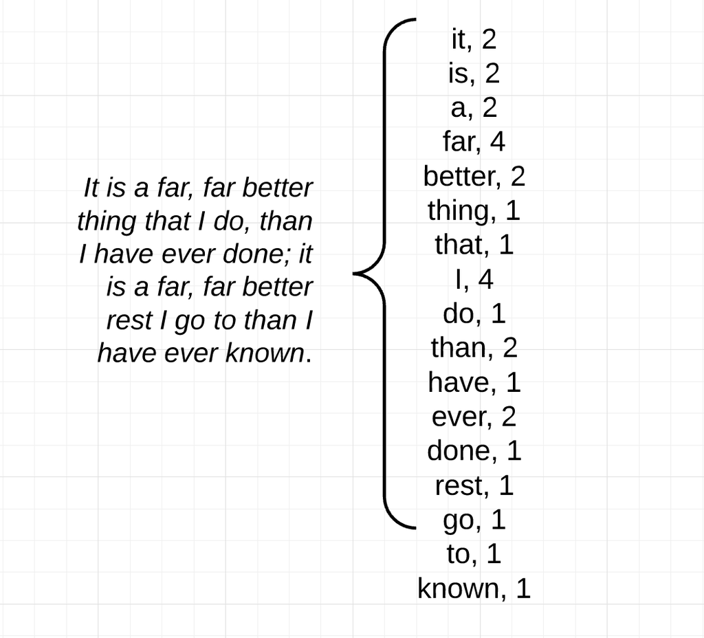

bag of words image

The power of the bag of words representation is that each document can be represented in the same vector space. We do so by defining the vector dimensions to reflect the vocabulary across all the documents. The vectors can then be merged into a matrix called a Document Term Matrix.

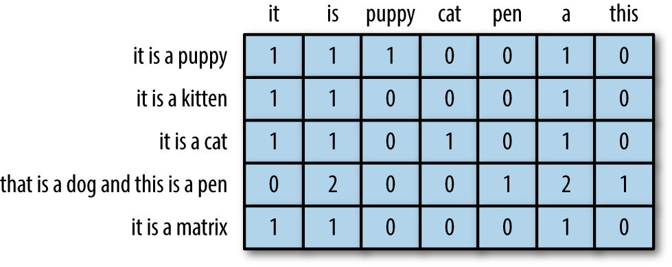

dtm image

# The Document Term Matrix

In brief, a Document Term Matrix:  
- each document is represented by a set of tokens and their counts  
- the order of tokens is not encoded in this representation  
- the basis of many text processing methods, including document classification and topic modeling

In R we can use a DocumentTermMatrix function from the ‘tm’ package to create this structure from our corpus.

#### a. Creating a Document Term Matrix from the corpus object

From the ‘corpus’ object we can create a document term matrix.

```r
mydtm <- DocumentTermMatrix(mycorpus)
```

Note: the DocumentTermMatrix automatically sets all the characters to lower case.

#### b. Exploring with a DTM

A useful tool is the inspect function from the ‘tm’ package.

```r
inspect(mydtm)
```

```
## <<DocumentTermMatrix (documents: 707, terms: 8153)>>
## Non-/sparse entries: 85319/5678852
## Sparsity           : 99%
## Maximal term length: 40
## Weighting          : term frequency (tf)
## Sample             :
##      Terms
## Docs  breast cancer dose patients radiation results therapy treated treatment
##   125      6      3    0        8         0       0       0       0         3
##   18       6      0    4        4         0       1       1       4         1
##   192     12      2    0       17         0       1       1       1         4
##   203     14     29    0        2         6       1       3       4         0
##   207     10      4    2        9         3       1       0       2         1
##   265      7      4    7        7         1       2       1       0         1
##   315      4      1    3        3         1       0       1       2         1
##   316      6      1   11        4         1       0       1       1         8
##   591      5      1    3       13         0       1       1       0         6
##   615      6      6    0       13         1       1       2       0         4
##      Terms
## Docs  years
##   125     2
##   18      0
##   192     3
##   203     6
##   207     5
##   265     0
##   315     0
##   316     0
##   591     5
##   615     2
```

From this format it we can find word counts and document lengths.

```r
document_lengths <- rowSums(as.matrix(mydtm))
word_counts <- colSums(as.matrix(mydtm))
```

We can get a sorted list of the biggest documents.

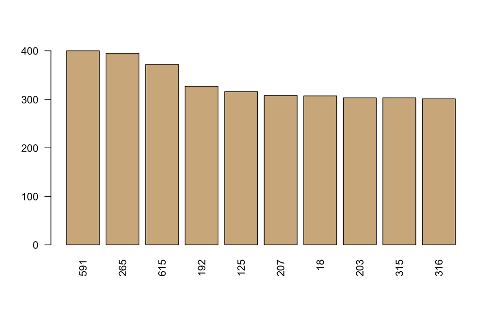

```r
sorted_document_lengths <- sort(document_lengths, decreasing=TRUE)
barplot(sorted_document_lengths[1:10], col = "tan", las = 2)
```

Or a sorted list of words and their frequencies.

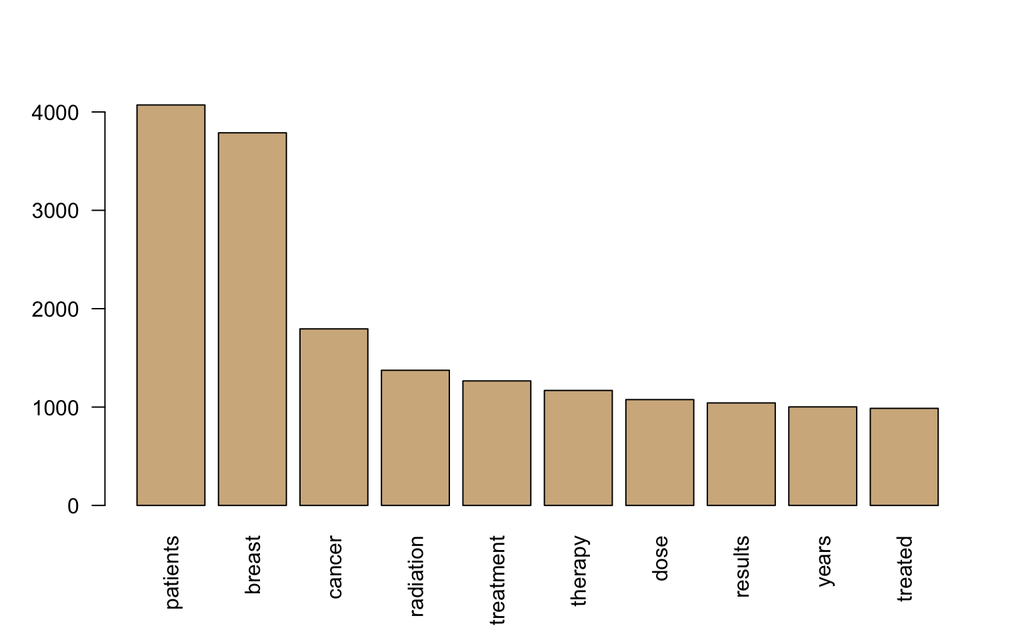

```r
sorted_word_counts <- sort(word_counts, decreasing=TRUE)
barplot(sorted_word_counts[1:10], col = "tan", las = 2)
```

# TF-IDF

TF-IDF stands for term frequency-inverse document frequency. It is a VERY popular method for finding documents relevant to a users search term. It can also be used as an effective (often times better than simple bag of words) representation of documents for statistical modeling of documents in a corpus.

#### a. Intuition behind TF-IDF

TF-IDF combines two attributes that may signal a words importance in a document into a single metric. The first is the ‘term frequency (TF)’ - how often the word appeared within that document. It makes intuitive sense that if a word appears many times in a document, that the document is about something related to that term. The second attribute is the ‘inverse document frequency (IDF)’ - a measure of what proportion of the documents the word appeared in. If a word appears in all documents, its weight should be reduced. Conversely, if a word appears only in few documents, it should be highly weighted for those documents.

#### b. TF-IDF formula

```
tfidf(t,d,D) = tf(t,d) * idf(t,D)
```

Where, tf(t,d) is a function of a terms(t) frequency for a given document(d). And, idf(t,D) is the inverse function of a terms(t) appearance across all the documents(D). There are many variations of functions for tf(t,d) and idf(t,D) that can be used for computing TF-IDF.

#### c. TF-IDF from DTM

Create tf-idf weighted DTM in R

```r
tfidf_dtm <- weightTfIdf(mydtm, normalize=TRUE)
```

#### d. Looking at the results

Inspect the new dtm

```r
inspect(tfidf_dtm)
```

```
## <<DocumentTermMatrix (documents: 707, terms: 8153)>>
## Non-/sparse entries: 85319/5678852
## Sparsity           : 99%
## Maximal term length: 40
## Weighting          : term frequency - inverse document frequency (normalized) (tf-idf)
## Sample             :
##      Terms
## Docs  apbi boost       dose grade group      local    survival   toxicity women
##   121    0     0 0.00000000     0     0 0.00000000 0.000000000 0.00000000     0
##   16     0     0 0.00000000     0     0 0.00000000 0.032285892 0.01516616     0
##   177    0     0 0.00928637     0     0 0.00000000 0.006872877 0.00000000     0
##   284    0     0 0.00000000     0     0 0.00000000 0.000000000 0.00000000     0
##   287    0     0 0.00000000     0     0 0.00000000 0.000000000 0.00000000     0
##   300    0     0 0.00000000     0     0 0.01270401 0.000000000 0.00000000     0
##   436    0     0 0.00000000     0     0 0.00000000 0.000000000 0.00000000     0
##   54     0     0 0.00000000     0     0 0.00000000 0.011520721 0.00000000     0
##   586    0     0 0.00000000     0     0 0.00000000 0.000000000 0.00000000     0
##   7      0     0 0.00000000     0     0 0.00000000 0.000000000 0.00000000     0
##      Terms
## Docs  years
##   121     0
##   16      0
##   177     0
##   284     0
##   287     0
##   300     0
##   436     0
##   54      0
##   586     0
##   7       0
```

Compare the tfidf representation with the tf representation for a single abstract

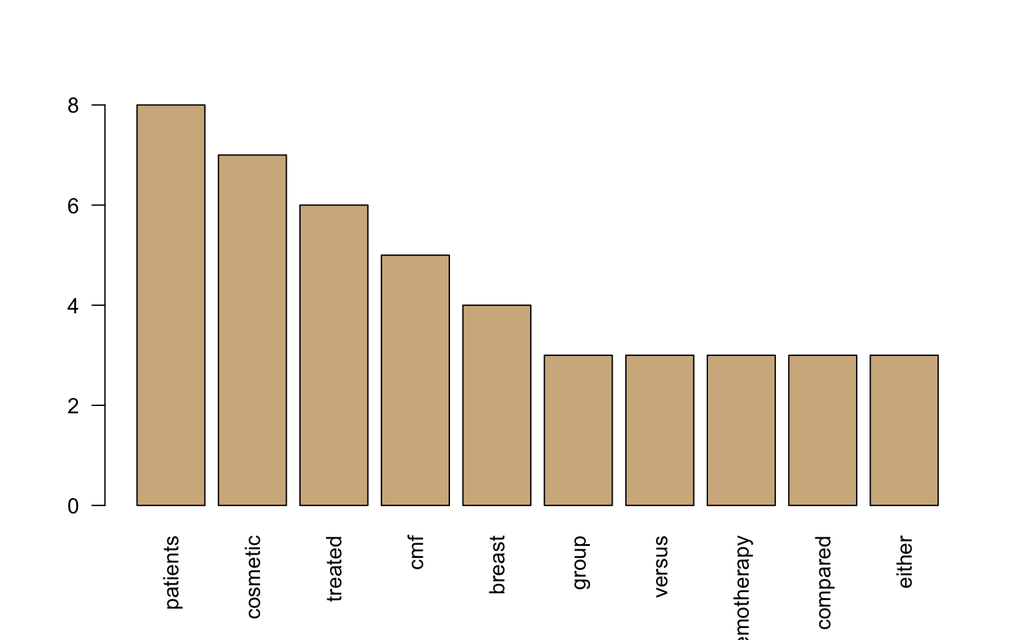

```r
tf_doc10 <- as.matrix(mydtm[10,])
tf <- colSums(tf_doc10)
tfidf_doc10 <- as.matrix(tfidf_dtm[10,])
tfidf <- colSums(tfidf_doc10)
barplot(sort(tf, decreasing=TRUE)[1:10], col = "tan", las = 2)
```

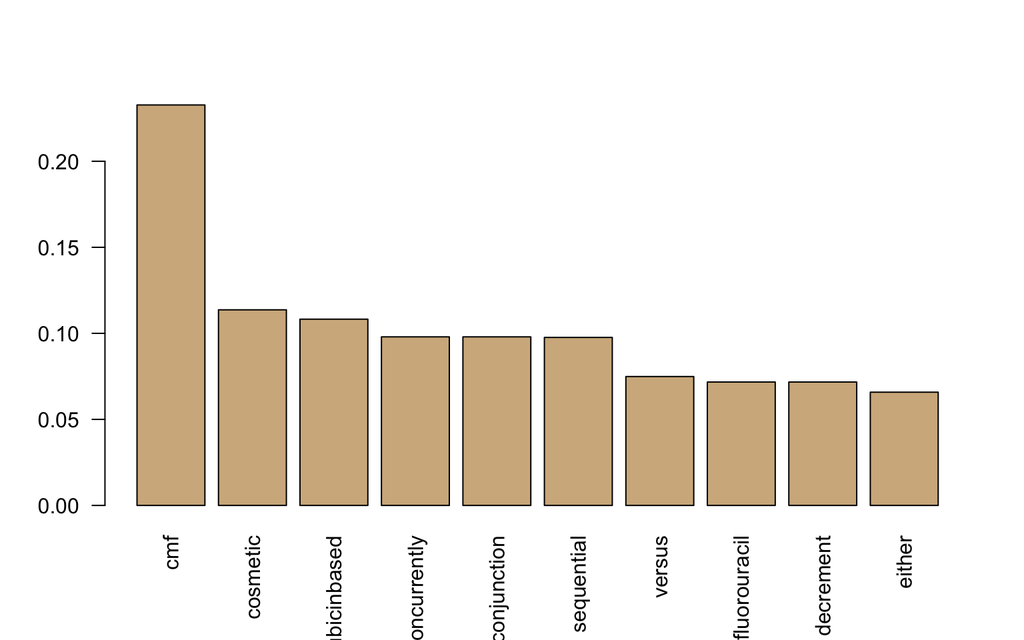

```r
barplot(sort(tfidf, decreasing=TRUE)[1:10], col = "tan", las = 2)
```

# PCA

#### a. Intuition behind PCA

Think of looking up at the night sky. You might see something like this:

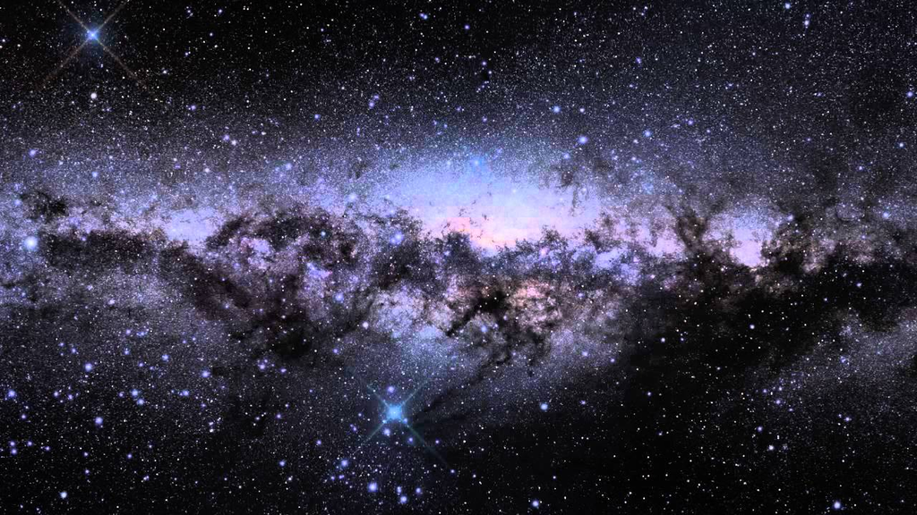

You can clearly see that the Milky Way has a major axis and a minor axis. But we know that our galaxy has a spiral shape - we just can’t see it because we’re looking from a particular perspective. If you took the coordinates of all the stars in our galaxy, you could rotate those coordinates to get an image like this:

[figure not shown]

This is analogous to principal components analysis (PCA). PCA rotates the data points to get a better perspective. The new coordinates are aligned by PCA so that the direction with the greatest variability comes first, then the next most, and so on. The analogy is that our perspective from Earth shows one axis of the Milky Way with a lot of variability, and one with only a little. PCA would rotate that view so the first two “principal components” show the galaxy’s spiral shape, with the third (showing its thickness being last).

#### b. Computing PCA

```r
articles <- t(tfidf_dtm)
mypca <- prcomp(articles, center=TRUE, scale=TRUE)
```

#### c. Plotting the abstracts

Add the principal components to the original data:

```r
plotdata <- cbind(data, mypca$rotation)
```

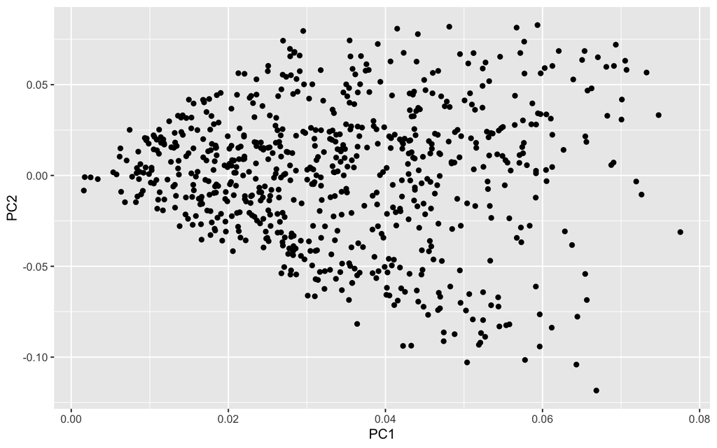

```r
ggplot(plotdata) + aes(x=PC1, y=PC2) + geom_point()
```

Now let’s identify some articles in the plot:

```r
min_index <- order(plotdata$PC1, decreasing=FALSE)
max_index <- order(plotdata$PC1, decreasing=TRUE)

# view the most divergent titles:
plotdata$title[min_index[1:6]]
```

```
## [1] "Signal transduction pathways regulated by CSF-1 receptors modulate the in vitro radiosensitivity of mammary epithelial cells."
## [2] "Creation of an episode-based payment model for prostate and breast cancer radiation therapy."
## [3] "Erratum to: Wang SY, Kelly G, Gross C, et al. Information needs of older women with early-stage breast cancer when making radiation therapy decisions. [Int J Radiat Oncol Biol Phys 2017;98:733-740](S0360301617303097)(10.1016/j.ijrobp.2017.02.001))."
## [4] "Molecular radiation therapy in experimental model of advanced prostate cancer using internalizable monoclonal antibody."
## [5] "Dna double-strand break repair and induction of apoptosis in relation to late normal tissue responses following radiation therapy for early breast cancer."
## [6] "Patient experience survey of early-stage breast cancer patients undergoing whole-breast radiation therapy."
```

```r
plotdata$title[max_index[1:6]]
```

```
## [1] "Differences in Patterns of Failure in Patients Treated With Accelerated Partial Breast Irradiation Versus Whole-Breast Irradiation: A Matched-Pair Analysis With 10-Year Follow-Up."
## [2] "Margin status an indication for accelerated partial breast irradiation in early-stage breast cancers."
## [3] "Daily Fractionation of External Beam Accelerated Partial Breast Irradiation to 40 Gy Is Well Tolerated and Locally Effective."
## [4] "Accelerated partial-breast irradiation provides equivalent 10-year outcomes to whole breast irradiation: A matched-pair analysis."
## [5] "Accelerated partial breast irradiation using sole interstitial multicatheter brachytherapy versus whole breast irradiation for early breast cancer: Five-year results of a randomized phase 3 trial-Part I: Local control and survival results."
## [6] "Phase I/II Study Evaluating Early Tolerance in Breast Cancer Patients Undergoing Accelerated Partial Breast Irradiation Treated With the MammoSite Balloon Breast Brachytherapy Catheter Using a 2-Day Dose Schedule."
```

Plot another pair of principal components:

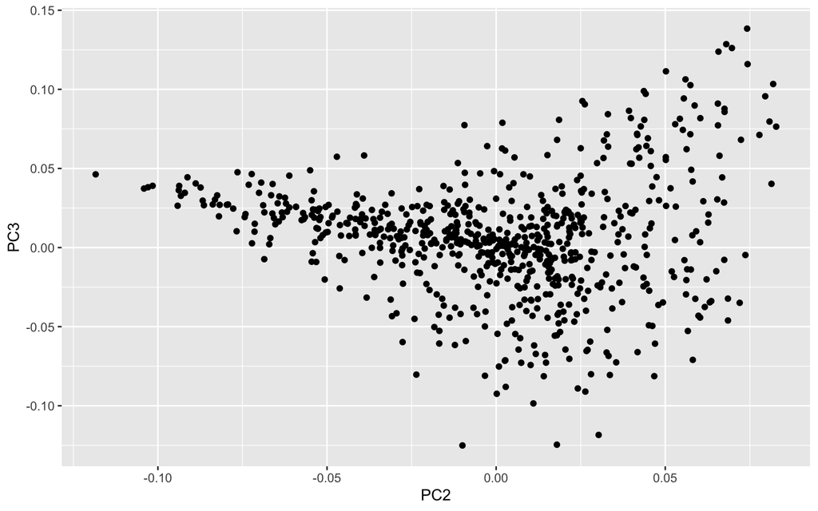

```r
ggplot(plotdata) + aes(x=PC2, y=PC3) + geom_point()
```

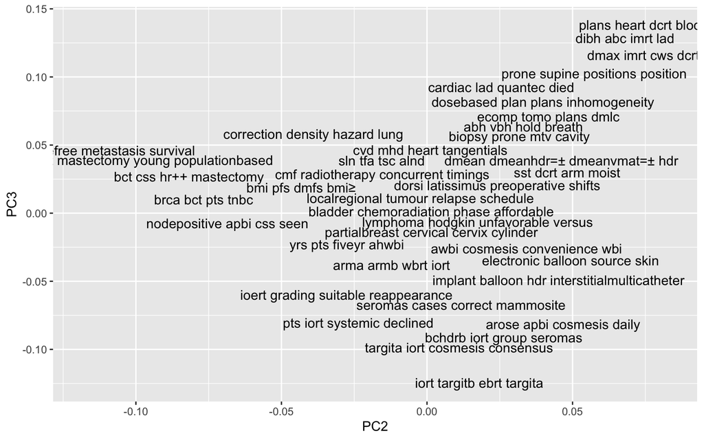

```r
source(url("https://ucdavisdatalab.github.io/workshop-nlp-healthcare/top_terms.R"))
plotdata[['top_terms']] <- top_terms(tfidf_dtm)
ggplot(plotdata) + aes(x=PC2, y=PC3, label=top_terms) + geom_text(check_overlap=TRUE)
```

Visualize the explained variance:

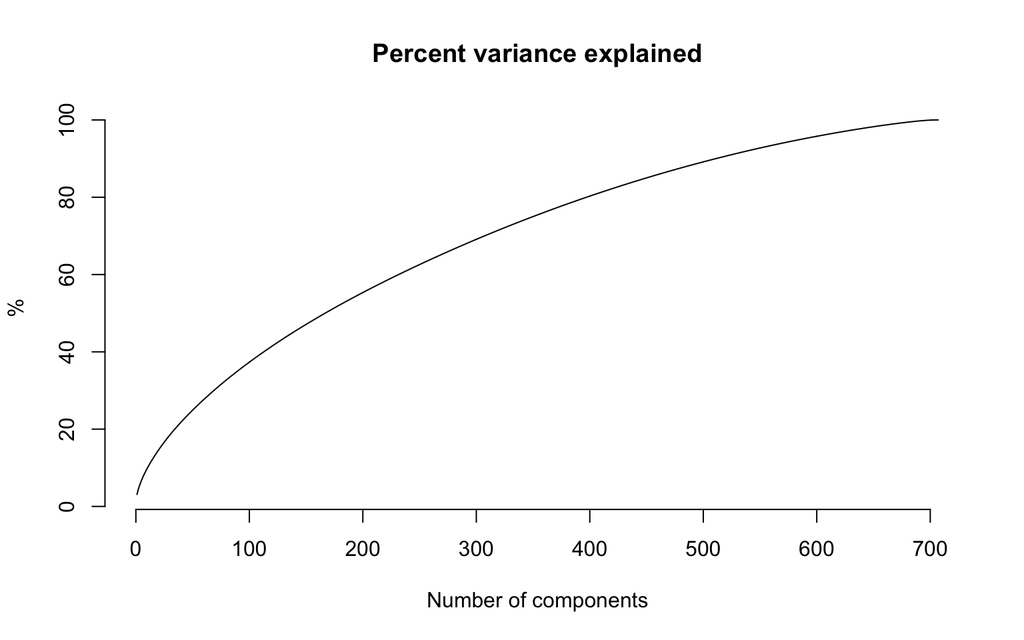

```r
plot(100 * cumsum(mypca$sdev^2) / sum(mypca$sdev^2), type='l', bty='n', ylab="%", xlab="Number of components", main="Percent variance explained")
```

# Further resources

Dr. Pamela Reynolds, Arthur Koehl, Dr. Wesley Brooks

February 10, 2020